# Flight delay Analysis and Prediction

# Visualization

```python
import seaborn as sns
import matplotlib as mp
import matplotlib.pyplot as plt
```

```python
final_trainA.dtypes
```

```
Unnamed: 0                    int64
ScheduledTravelTime           int64
Origin                       object
Destination                  object
Distance                      int64
GroundHeight                float64
StationHeight               float64
BarometerHeight             float64
SkyConditions                object
Visibility                   object
DBT                         float64
DewPointTemp                float64
RelativeHumidityPercent     float64
WindSpeed                   float64
WindDirection                object
WindGustValue               float64
StationPressure             float64
HourlyPrecip                float64
GroundHeight1               float64
StationHeight1              float64
BarometerHeight1            float64
SkyConditions1               object
Visibility1                  object
DBT1                        float64
DewPointTemp1               float64
RelativeHumidityPercent1    float64
WindSpeed1                  float64
WindDirection1               object
WindGustValue1              float64
StationPressure1            float64
HourlyPrecip1               float64
FlightDelay                  object
dtype: object
```

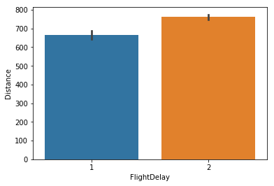

```python
#checking delay as per distance
sns.barplot(x='FlightDelay',y='Distance',data=final_trainA)
```

[output not shown]

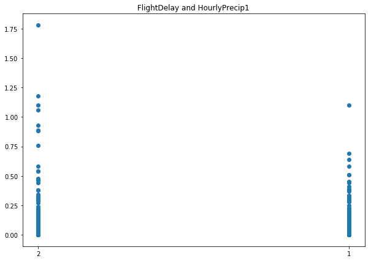

```python
plt.figure(figsize = (10,7))

plt.scatter(x = final_trainA.FlightDelay,y = final_trainA.HourlyPrecip1)
plt.title('FlightDelay and HourlyPrecip1')
plt.show
```

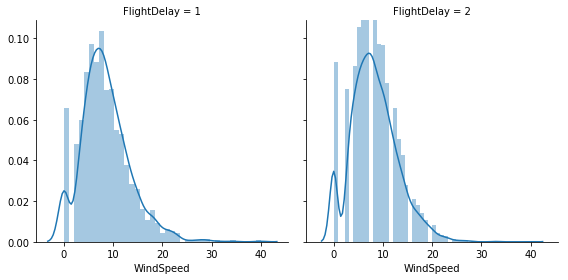

```python
final_trainA['WindSpeed']=final_trainA['WindSpeed'].astype('int64')

g = sns.FacetGrid(final_trainA,col='FlightDelay',size = 4)
g.map(sns.distplot,'WindSpeed')
plt.show()
```

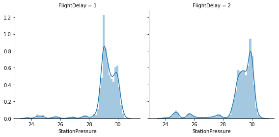

```python
g = sns.FacetGrid(final_trainA,col='FlightDelay',size = 4)
g.map(sns.distplot,'StationPressure')
plt.show()
```

drop columns not required

```python
final_trainA=final_trainA.drop('Origin',axis=1)
final_trainA=final_trainA.drop('Destination',axis=1)


final_testA=final_testA.drop('Origin',axis=1)
final_testA=final_testA.drop('Destination',axis=1)
```

# label encoding

```python
from sklearn.preprocessing import LabelEncoder
T = LabelEncoder()
final_trainA['New_SkyConditions'] = T.fit_transform(final_trainA.SkyConditions)
final_trainA['New_SkyConditions1'] = T.fit_transform(final_trainA.SkyConditions1)
final_testA['New_SkyConditions'] = T.fit_transform(final_testA.SkyConditions)
final_testA['New_SkyConditions1'] = T.fit_transform(final_testA.SkyConditions1)
```

```python
#drop feature
final_trainA=final_trainA.drop('SkyConditions',axis=1)
final_trainA=final_trainA.drop('SkyConditions1',axis=1)

final_testA=final_testA.drop('SkyConditions',axis=1)
final_testA=final_testA.drop('SkyConditions1',axis=1)
```

```python
#removing characters infrond of number

final_trainA["Visibility"] = final_trainA.Visibility.str.replace('[SM]', '')
final_testA["Visibility"] = final_testA.Visibility.str.replace('[SM]', '')


final_trainA["Visibility1"] = final_trainA.Visibility1.str.replace('[SM]', '')
final_testA["Visibility1"] = final_testA.Visibility1.str.replace('[SM]', '')
```

```python
final_trainA.T
```

|  | 0 | 1 | 2 | 3 | 4 | 5 | 6 | 7 | 8 | 9 | ... | 7851 | 7852 | 7853 | 7854 | 7855 | 7856 | 7857 | 7858 | 7859 | 7860 |
| --- | --- | --- | --- | --- | --- | --- | --- | --- | --- | --- | --- | --- | --- | --- | --- | --- | --- | --- | --- | --- | --- |
| Unnamed: 0 | 0 | 4 | 5 | 7 | 8 | 9 | 10 | 11 | 12 | 13 | ... | 9415 | 9416 | 9417 | 9418 | 9419 | 9421 | 9422 | 9423 | 9424 | 9425 |
| ScheduledTravelTime | 114 | 114 | 62 | 93 | 76 | 62 | 107 | 63 | 120 | 156 | ... | 85 | 80 | 352 | 165 | 66 | 145 | 179 | 75 | 104 | 168 |
| Distance | 563 | 554 | 226 | 508 | 334 | 268 | 551 | 250 | 597 | 1068 | ... | 414 | 235 | 2475 | 998 | 270 | 861 | 946 | 239 | 546 | 1062 |
| GroundHeight | 19 | 802 | 49 | 721 | 871 | 882 | 559 | 222 | 636 | 559 | ... | 977 | 655 | 29 | 25 | 971 | 118 | 25 | 306 | 810.35 | 117 |
| StationHeight | 30 | 805 | 55 | 769 | 838 | 883 | 596 | 210 | 630 | 596 | ... | 980 | 674 | 22 | 30 | 1026 | 108 | 30 | 323 | 817.165 | 11 |
| BarometerHeight | 180 | 805 | 52 | 724 | 874 | 885 | 562 | 225 | 639 | 562 | ... | 980 | 658 | 32 | 28 | 974 | 121 | 28 | 309 | 816.289 | 120 |
| Visibility | 10 | 6 | 7 | 10 | 10 | 10 | 10 | 10 | 10 | 10 | ... | 10 | 10 | 10 | 10 | 10 | 10 | 10 | 9 | 10 | 6 |
| DBT | 63 | 53 | 69 | 90 | 68 | 72 | 80 | 58 | 74 | 79 | ... | 63 | 83 | 70 | 72 | 89 | 80 | 48 | 85 | 67 | 74 |
| DewPointTemp | 40 | 50 | 61 | 66 | 58 | 49 | 59 | 52 | 68 | 62 | ... | 54 | 65 | 57 | 59 | 71 | 72 | 26 | 60 | 52 | 73 |
| RelativeHumidityPercent | 43 | 89 | 76 | 45 | 70 | 44 | 49 | 81 | 82 | 56 | ... | 73 | 55 | 64 | 64 | 55 | 76 | 42 | 43 | 63 | 97 |
| WindSpeed | 6 | 7 | 7 | 0 | 10 | 7 | 14 | 0 | 11 | 3 | ... | 4 | 10 | 11 | 8 | 6 | 11 | 14 | 7 | 8 | 0 |
| WindDirection | 340 | 110 | 220 | 000 | 130 | 080 | 180 | 000 | 030 | 100 | ... | 200 | 320 | 110 | 110 | 330 | 210 | 330 | 310 | 0 | 000 |
| WindGustValue | 0 | 0 | 0 | 0 | 0 | 0 | 0 | 0 | 0 | 0 | ... | 0 | 0 | 0 | 0 | 0 | 16 | 18 | 0 | 3 | 0 |
| StationPressure | 30.28 | 29.21 | 29.82 | 29.26 | 29.02 | 29.14 | 29.43 | 29.8 | 29.25 | 29.51 | ... | 29.29 | 29.22 | 30.37 | 30.26 | 29.07 | 29.75 | 30.24 | 29.83 | 29 | 29.8 |
| HourlyPrecip | 0 | 0.01 | 0 | 0 | 0 | 0 | 0 | 0 | 0 | 0 | ... | 0 | 0 | 0 | 0 | 0 | 0 | 0 | 0 | 0 | 0.02 |
| GroundHeight1 | 802 | 971 | 2127 | 8 | 655 | 785 | 707 | 86 | 559 | 1172 | ... | 10 | 628 | 323 | 8 | 31 | 5379 | 283 | 904 | 838 | 802 |
| StationHeight1 | 805 | 1026 | 2180 | 11 | 674 | 803 | 710 | 18 | 596 | 1203 | ... | 65 | 664 | 326 | 11 | 32 | 5431 | 332 | 886 | 847 | 805 |
| BarometerHeight1 | 805 | 974 | 2091 | 40 | 658 | 788 | 710 | 89 | 562 | 1175 | ... | 3 | 631 | 326 | 40 | 34 | 5382 | 286 | 907 | 843 | 805 |
| Visibility1 | 10 | 2 | 10 | 10 | 10 | 10 | 10 | 9 | 10 | 10 | ... | 10 | 8 | 10 | 10 | 10 | 10 | 10 | 10 | 10 | 10 |
| DBT1 | 71 | 68 | 89 | 88 | 79 | 65 | 80 | 68 | 90 | 74 | ... | 71 | 78 | 77 | 82 | 95 | 71 | 62 | 83 | 68 | 57 |
| DewPointTemp1 | 35 | 52 | 25 | 76 | 55 | 45 | 60 | 55 | 56 | 56 | ... | 52 | 70 | 63 | 74 | 74 | 33 | 43 | 58 | 52 | 40 |
| RelativeHumidityPercent1 | 27 | 61 | 10 | 68 | 44 | 49 | 51 | 63 | 32 | 54 | ... | 51 | 76 | 62 | 77 | 51 | 25 | 50 | 43 | 61 | 53 |
| WindSpeed1 | 8 | 9 | 8 | 7 | 8 | 3 | 6 | 0 | 5 | 5 | ... | 3 | 0 | 10 | 20 | 7 | 18 | 8 | 9 | 8 | 8 |
| WindDirection1 | 190 | 150 | 190 | 010 | 200 | 020 | 220 | 000 | 0 | 070 | ... | 340 | 000 | 230 | 190 | 340 | 290 | 120 | 190 | 0 | 230 |
| WindGustValue1 | 0 | 0 | 0 | 0 | 0 | 0 | 0 | 0 | 0 | 0 | ... | 0 | 0 | 0 | 27 | 0 | 24 | 0 | 0 | 2.7 | 0 |
| StationPressure1 | 29.49 | 29 | 27.58 | 30.03 | 29.49 | 29.31 | 29.17 | 29.77 | 29.19 | 28.97 | ... | 30.31 | 29.21 | 29.43 | 29.63 | 30.01 | 24.51 | 29.66 | 29.21 | 29 | 28.96 |
| HourlyPrecip1 | 0 | 0 | 0 | 0 | 0 | 0 | 0 | 0 | 0 | 0 | ... | 0 | 0 | 0 | 0 | 0 | 0 | 0 | 0 | 0 | 0 |
| FlightDelay | 2 | 1 | 2 | 2 | 2 | 2 | 2 | 2 | 1 | 2 | ... | 2 | 2 | 2 | 1 | 2 | 2 | 2 | 2 | 2 | 1 |
| New_SkyConditions | 717 | 2345 | 717 | 1730 | 2005 | 715 | 717 | 2336 | 2716 | 2145 | ... | 717 | 1702 | 1404 | 2959 | 1775 | 2638 | 696 | 1820 | 717 | 459 |
| New_SkyConditions1 | 2324 | 2446 | 659 | 1466 | 2316 | 659 | 659 | 659 | 2053 | 2993 | ... | 656 | 1530 | 2965 | 1171 | 3107 | 2090 | 3219 | 3215 | 659 | 3428 |

30 rows × 7856 columns

# creating new feature

```python
final_trainA['Speed'] =final_trainA['Distance'] / final_trainA['ScheduledTravelTime']
```

```python
final_testA['Speed'] =final_testA['Distance'] / final_testA['ScheduledTravelTime']
```

```python
final_trainA.T
```

|  | 0 | 1 | 2 | 3 | 4 | 5 | 6 | 7 | 8 | 9 | ... | 7851 | 7852 | 7853 | 7854 | 7855 | 7856 | 7857 | 7858 | 7859 | 7860 |
| --- | --- | --- | --- | --- | --- | --- | --- | --- | --- | --- | --- | --- | --- | --- | --- | --- | --- | --- | --- | --- | --- |
| Unnamed: 0 | 0 | 4 | 5 | 7 | 8 | 9 | 10 | 11 | 12 | 13 | ... | 9415 | 9416 | 9417 | 9418 | 9419 | 9421 | 9422 | 9423 | 9424 | 9425 |
| ScheduledTravelTime | 114 | 114 | 62 | 93 | 76 | 62 | 107 | 63 | 120 | 156 | ... | 85 | 80 | 352 | 165 | 66 | 145 | 179 | 75 | 104 | 168 |
| Distance | 563 | 554 | 226 | 508 | 334 | 268 | 551 | 250 | 597 | 1068 | ... | 414 | 235 | 2475 | 998 | 270 | 861 | 946 | 239 | 546 | 1062 |
| GroundHeight | 19 | 802 | 49 | 721 | 871 | 882 | 559 | 222 | 636 | 559 | ... | 977 | 655 | 29 | 25 | 971 | 118 | 25 | 306 | 810.35 | 117 |
| StationHeight | 30 | 805 | 55 | 769 | 838 | 883 | 596 | 210 | 630 | 596 | ... | 980 | 674 | 22 | 30 | 1026 | 108 | 30 | 323 | 817.165 | 11 |
| BarometerHeight | 180 | 805 | 52 | 724 | 874 | 885 | 562 | 225 | 639 | 562 | ... | 980 | 658 | 32 | 28 | 974 | 121 | 28 | 309 | 816.289 | 120 |
| Visibility | 10 | 6 | 7 | 10 | 10 | 10 | 10 | 10 | 10 | 10 | ... | 10 | 10 | 10 | 10 | 10 | 10 | 10 | 9 | 10 | 6 |
| DBT | 63 | 53 | 69 | 90 | 68 | 72 | 80 | 58 | 74 | 79 | ... | 63 | 83 | 70 | 72 | 89 | 80 | 48 | 85 | 67 | 74 |
| DewPointTemp | 40 | 50 | 61 | 66 | 58 | 49 | 59 | 52 | 68 | 62 | ... | 54 | 65 | 57 | 59 | 71 | 72 | 26 | 60 | 52 | 73 |
| RelativeHumidityPercent | 43 | 89 | 76 | 45 | 70 | 44 | 49 | 81 | 82 | 56 | ... | 73 | 55 | 64 | 64 | 55 | 76 | 42 | 43 | 63 | 97 |
| WindSpeed | 6 | 7 | 7 | 0 | 10 | 7 | 14 | 0 | 11 | 3 | ... | 4 | 10 | 11 | 8 | 6 | 11 | 14 | 7 | 8 | 0 |
| WindDirection | 340 | 110 | 220 | 000 | 130 | 080 | 180 | 000 | 030 | 100 | ... | 200 | 320 | 110 | 110 | 330 | 210 | 330 | 310 | 0 | 000 |
| WindGustValue | 0 | 0 | 0 | 0 | 0 | 0 | 0 | 0 | 0 | 0 | ... | 0 | 0 | 0 | 0 | 0 | 16 | 18 | 0 | 3 | 0 |
| StationPressure | 30.28 | 29.21 | 29.82 | 29.26 | 29.02 | 29.14 | 29.43 | 29.8 | 29.25 | 29.51 | ... | 29.29 | 29.22 | 30.37 | 30.26 | 29.07 | 29.75 | 30.24 | 29.83 | 29 | 29.8 |
| HourlyPrecip | 0 | 0.01 | 0 | 0 | 0 | 0 | 0 | 0 | 0 | 0 | ... | 0 | 0 | 0 | 0 | 0 | 0 | 0 | 0 | 0 | 0.02 |
| GroundHeight1 | 802 | 971 | 2127 | 8 | 655 | 785 | 707 | 86 | 559 | 1172 | ... | 10 | 628 | 323 | 8 | 31 | 5379 | 283 | 904 | 838 | 802 |
| StationHeight1 | 805 | 1026 | 2180 | 11 | 674 | 803 | 710 | 18 | 596 | 1203 | ... | 65 | 664 | 326 | 11 | 32 | 5431 | 332 | 886 | 847 | 805 |
| BarometerHeight1 | 805 | 974 | 2091 | 40 | 658 | 788 | 710 | 89 | 562 | 1175 | ... | 3 | 631 | 326 | 40 | 34 | 5382 | 286 | 907 | 843 | 805 |
| Visibility1 | 10 | 2 | 10 | 10 | 10 | 10 | 10 | 9 | 10 | 10 | ... | 10 | 8 | 10 | 10 | 10 | 10 | 10 | 10 | 10 | 10 |
| DBT1 | 71 | 68 | 89 | 88 | 79 | 65 | 80 | 68 | 90 | 74 | ... | 71 | 78 | 77 | 82 | 95 | 71 | 62 | 83 | 68 | 57 |
| DewPointTemp1 | 35 | 52 | 25 | 76 | 55 | 45 | 60 | 55 | 56 | 56 | ... | 52 | 70 | 63 | 74 | 74 | 33 | 43 | 58 | 52 | 40 |
| RelativeHumidityPercent1 | 27 | 61 | 10 | 68 | 44 | 49 | 51 | 63 | 32 | 54 | ... | 51 | 76 | 62 | 77 | 51 | 25 | 50 | 43 | 61 | 53 |
| WindSpeed1 | 8 | 9 | 8 | 7 | 8 | 3 | 6 | 0 | 5 | 5 | ... | 3 | 0 | 10 | 20 | 7 | 18 | 8 | 9 | 8 | 8 |
| WindDirection1 | 190 | 150 | 190 | 010 | 200 | 020 | 220 | 000 | 0 | 070 | ... | 340 | 000 | 230 | 190 | 340 | 290 | 120 | 190 | 0 | 230 |
| WindGustValue1 | 0 | 0 | 0 | 0 | 0 | 0 | 0 | 0 | 0 | 0 | ... | 0 | 0 | 0 | 27 | 0 | 24 | 0 | 0 | 2.7 | 0 |
| StationPressure1 | 29.49 | 29 | 27.58 | 30.03 | 29.49 | 29.31 | 29.17 | 29.77 | 29.19 | 28.97 | ... | 30.31 | 29.21 | 29.43 | 29.63 | 30.01 | 24.51 | 29.66 | 29.21 | 29 | 28.96 |
| HourlyPrecip1 | 0 | 0 | 0 | 0 | 0 | 0 | 0 | 0 | 0 | 0 | ... | 0 | 0 | 0 | 0 | 0 | 0 | 0 | 0 | 0 | 0 |
| FlightDelay | 2 | 1 | 2 | 2 | 2 | 2 | 2 | 2 | 1 | 2 | ... | 2 | 2 | 2 | 1 | 2 | 2 | 2 | 2 | 2 | 1 |
| New_SkyConditions | 717 | 2345 | 717 | 1730 | 2005 | 715 | 717 | 2336 | 2716 | 2145 | ... | 717 | 1702 | 1404 | 2959 | 1775 | 2638 | 696 | 1820 | 717 | 459 |
| New_SkyConditions1 | 2324 | 2446 | 659 | 1466 | 2316 | 659 | 659 | 659 | 2053 | 2993 | ... | 656 | 1530 | 2965 | 1171 | 3107 | 2090 | 3219 | 3215 | 659 | 3428 |
| Speed | 4.9386 | 4.85965 | 3.64516 | 5.46237 | 4.39474 | 4.32258 | 5.14953 | 3.96825 | 4.975 | 6.84615 | ... | 4.87059 | 2.9375 | 7.03125 | 6.04848 | 4.09091 | 5.93793 | 5.28492 | 3.18667 | 5.25 | 6.32143 |

31 rows × 7856 columns

```python
#Drop Features

final_trainA.drop("ScheduledTravelTime",axis=1, inplace=True)
final_testA.drop("ScheduledTravelTime",axis=1, inplace=True)
```

```python
final_trainA.drop("Unnamed: 0",axis=1, inplace=True)
final_testA.drop("Unnamed: 0",axis=1, inplace=True)
```

```python
train_y = final_trainA["FlightDelay"].copy()
train_y=final_trainA.FlightDelay
final_trainA.drop("FlightDelay",axis=1, inplace=True)
```

splitting of data to train and test

```python
#splitting

import sklearn
from sklearn.model_selection import train_test_split
X_train, X_test, y_train, y_test = train_test_split(final_trainA, train_y, random_state=1)

print(X_train.shape)
print(X_test.shape)
print(y_train.shape)
print(y_test.shape)
```

```
(5892, 28)
(1964, 28)
(5892,)
(1964,)
```

```python
# change data type
X_train['Visibility'] = X_train['Visibility'].astype('float64')
X_train['WindDirection'] = X_train['WindDirection'].astype('int64')
X_train['Visibility1'] = X_train['Visibility1'].astype('float64')
X_train['WindDirection1'] = X_train['WindDirection1'].astype('int64')

X_test['Visibility'] = X_test['Visibility'].astype('float64')
X_test['WindDirection'] = X_test['WindDirection'].astype('int64')
X_test['Visibility1'] = X_test['Visibility1'].astype('float64')
X_test['WindDirection1'] = X_test['WindDirection1'].astype('int64')

final_testA['Visibility'] = final_testA['Visibility'].astype('float64')
final_testA['WindDirection'] = final_testA['WindDirection'].astype('int64')
final_testA['Visibility1'] = final_testA['Visibility1'].astype('float64')
final_testA['WindDirection1'] = final_testA['WindDirection1'].astype('int64')
```

[output not shown]

```python
final_testA.dtypes
```

```
Distance                      int64
GroundHeight                float64
StationHeight               float64
BarometerHeight             float64
Visibility                  float64
DBT                         float64
DewPointTemp                float64
RelativeHumidityPercent     float64
WindSpeed                   float64
WindDirection                 int64
WindGustValue               float64
StationPressure             float64
HourlyPrecip                float64
GroundHeight1               float64
StationHeight1              float64
BarometerHeight1            float64
Visibility1                 float64
DBT1                        float64
DewPointTemp1               float64
RelativeHumidityPercent1    float64
WindSpeed1                  float64
WindDirection1                int64
WindGustValue1              float64
StationPressure1            float64
HourlyPrecip1               float64
New_SkyConditions             int32
New_SkyConditions1            int32
Speed                       float64
dtype: object
```

```python
#taking all numeric values in one

num_values1=X_train.select_dtypes(['float64','int64','int32']).columns
```

# standardising data

```python
from sklearn.preprocessing import StandardScaler

scaler = StandardScaler()
scaler.fit(X_train[num_values1])
X_train[num_values1]=scaler.transform(X_train[num_values1])
X_test[num_values1]=scaler.transform(X_test[num_values1])
final_testA[num_values1]=scaler.transform(final_testA[num_values1])
```

[output not shown]

```python
X_train.describe()
```

|  | Distance | GroundHeight | StationHeight | BarometerHeight | Visibility | DBT | DewPointTemp | RelativeHumidityPercent | WindSpeed | WindDirection | ... | DewPointTemp1 | RelativeHumidityPercent1 | WindSpeed1 | WindDirection1 | WindGustValue1 | StationPressure1 | HourlyPrecip1 | New_SkyConditions | New_SkyConditions1 | Speed |
| --- | --- | --- | --- | --- | --- | --- | --- | --- | --- | --- | --- | --- | --- | --- | --- | --- | --- | --- | --- | --- | --- |
| count | 5.892000e+03 | 5.892000e+03 | 5.892000e+03 | 5.892000e+03 | 5.892000e+03 | 5.892000e+03 | 5.892000e+03 | 5.892000e+03 | 5.892000e+03 | 5.892000e+03 | ... | 5.892000e+03 | 5.892000e+03 | 5.892000e+03 | 5.892000e+03 | 5.892000e+03 | 5.892000e+03 | 5.892000e+03 | 5.892000e+03 | 5.892000e+03 | 5.892000e+03 |
| mean | -2.830202e-17 | 1.562076e-17 | -1.378546e-16 | -9.193446e-17 | 1.176456e-15 | 1.775471e-16 | -1.354615e-16 | -8.109037e-17 | 1.152054e-16 | 1.559814e-16 | ... | 1.522034e-16 | 9.146338e-17 | 1.811744e-16 | -8.873116e-17 | -1.703906e-15 | -2.400207e-16 | 4.433449e-16 | 6.937010e-17 | -2.381741e-17 | 1.249284e-16 |
| std | 1.000085e+00 | 1.000085e+00 | 1.000085e+00 | 1.000085e+00 | 1.000085e+00 | 1.000085e+00 | 1.000085e+00 | 1.000085e+00 | 1.000085e+00 | 1.000085e+00 | ... | 1.000085e+00 | 1.000085e+00 | 1.000085e+00 | 1.000085e+00 | 1.000085e+00 | 1.000085e+00 | 1.000085e+00 | 1.000085e+00 | 1.000085e+00 | 1.000085e+00 |
| min | -1.278877e+00 | -6.794296e-01 | -6.798292e-01 | -6.859556e-01 | -3.558180e+00 | -3.887339e+00 | -3.748813e+00 | -2.802459e+00 | -1.773650e+00 | -1.436320e+00 | ... | -5.304917e+00 | -2.715603e+00 | -1.810943e+00 | -1.471288e+00 | -3.744390e-01 | -4.547340e+00 | -1.262748e-01 | -1.768416e+00 | -1.765572e+00 | -3.471911e+00 |
| 25% | -7.205473e-01 | -6.064609e-01 | -6.065350e-01 | -5.857131e-01 | 8.925036e-02 | -5.803602e-01 | -6.423039e-01 | -6.760009e-01 | -7.047360e-01 | -9.014956e-01 | ... | -6.531570e-01 | -6.732115e-01 | -7.191072e-01 | -9.263127e-01 | -3.744390e-01 | -1.210728e-01 | -1.262748e-01 | -1.025221e+00 | -1.087312e+00 | -6.624734e-01 |
| 50% | -2.850117e-01 | -2.105847e-01 | -1.834276e-01 | -2.135340e-01 | 4.945204e-01 | 1.471752e-01 | 1.508472e-01 | -1.443624e-02 | -6.338742e-02 | 7.901646e-02 | ... | 2.107413e-01 | -8.246763e-03 | -6.400547e-02 | 7.280825e-02 | -3.744390e-01 | 2.242093e-01 | -1.262748e-01 | 1.087467e-01 | 1.189396e-01 | 2.978626e-02 |
| 75% | 3.922749e-01 | 6.032214e-02 | 5.561140e-02 | 5.798234e-02 | 4.945204e-01 | 7.424313e-01 | 8.118065e-01 | 7.888923e-01 | 5.779612e-01 | 7.921161e-01 | ... | 8.088247e-01 | 7.517130e-01 | 5.910963e-01 | 7.994417e-01 | -3.744390e-01 | 5.861315e-01 | -1.262748e-01 | 6.622558e-01 | 6.543940e-01 | 7.268473e-01 |
| max | 8.093772e+00 | 4.503865e+00 | 4.459093e+00 | 4.511523e+00 | 4.945204e-01 | 2.462060e+00 | 1.803245e+00 | 1.733985e+00 | 6.777664e+00 | 1.772628e+00 | ... | 1.739177e+00 | 1.844155e+00 | 5.613543e+00 | 1.798563e+00 | 5.620136e+00 | 1.409816e+00 | 3.246083e+01 | 1.788968e+00 | 1.767758e+00 | 2.950306e+00 |

8 rows × 28 columns

[output not shown]

[output cut: 10 more lines]

[output not shown]

Overview

Dataset info

| Number of variables | 29 |
| --- | --- |
| Number of observations | 5892 |
| Total Missing (%) | 0.0% |
| Total size in memory | 1.3 MiB |
| Average record size in memory | 232.0 B |

Variables types

| Numeric | 25 |
| --- | --- |
| Categorical | 0 |
| Boolean | 0 |
| Date | 0 |
| Text (Unique) | 0 |
| Rejected | 4 |
| Unsupported | 0 |

Warnings

- `BarometerHeight` is highly correlated with `StationHeight` (ρ = 0.9994) Rejected

- `BarometerHeight1` is highly correlated with `StationHeight1` (ρ = 0.99683) Rejected

- `StationHeight` is highly correlated with `GroundHeight` (ρ = 0.99958) Rejected

- `StationHeight1` is highly correlated with `GroundHeight1` (ρ = 0.99702) Rejected

Variables

BarometerHeight  
Highly correlated

*This variable is highly correlated with `StationHeight` and should be ignored for analysis*

| Correlation | 0.9994 |
| --- | --- |

BarometerHeight1  
Highly correlated

*This variable is highly correlated with `StationHeight1` and should be ignored for analysis*

| Correlation | 0.99683 |
| --- | --- |

DBT  
Numeric

| Distinct count | 91 |
| --- | --- |
| Unique (%) | 1.5% |
| Missing (%) | 0.0% |
| Missing (n) | 0 |
| Infinite (%) | 0.0% |
| Infinite (n) | 0 |

| Mean | 1.7755e-16 |
| --- | --- |
| Minimum | -3.8873 |
| Maximum | 2.4621 |
| Zeros (%) | 0.0% |

Toggle details

**Statistics**

Quantile statistics

| Minimum | -3.8873 |
| --- | --- |
| 5-th percentile | -1.9032 |
| Q1 | -0.58036 |
| Median | 0.14718 |
| Q3 | 0.74243 |
| 95-th percentile | 1.4038 |
| Maximum | 2.4621 |
| Range | 6.3494 |
| Interquartile range | 1.3228 |

Descriptive statistics

| Standard deviation | 1.0001 |
| --- | --- |
| Coef of variation | 5632800000000000 |
| Kurtosis | 0.12132 |
| Mean | 1.7755e-16 |
| MAD | 0.79366 |
| Skewness | -0.60411 |
| Sum | 9.0239e-13 |
| Variance | 1.0002 |
| Memory size | 46.1 KiB |

**Histogram**

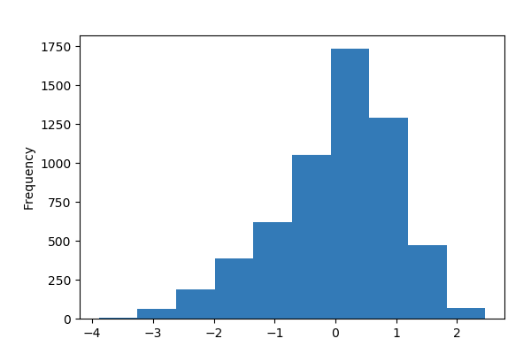

**Common Values**

| Value | Count | Frequency (%) |  |
| --- | --- | --- | --- |
| -0.05124357940429593 | 300 | 5.1% |  |
| 0.5440126152618624 | 184 | 3.1% |  |
| 0.41173346089160495 | 178 | 3.0% |  |
| 0.8085709240023772 | 171 | 2.9% |  |
| 0.08103557496596148 | 169 | 2.9% |  |
| 0.610152192446991 | 166 | 2.8% |  |
| 0.47787303807673365 | 163 | 2.8% |  |
| 0.34559388370647626 | 159 | 2.7% |  |
| 0.21331472933621887 | 158 | 2.7% |  |
| 0.6762917696321198 | 152 | 2.6% |  |
| Other values (81) | 4092 | 69.5% |  |

**Extreme Values**

Minimum 5 values

| Value | Count | Frequency (%) |  |
| --- | --- | --- | --- |
| -3.8873390561417605 | 1 | 0.0% |  |
| -3.5566411702161167 | 1 | 0.0% |  |
| -3.4243620158458596 | 2 | 0.0% |  |
| -3.292082861475602 | 2 | 0.0% |  |
| -3.2259432842904734 | 3 | 0.1% |  |

Maximum 5 values

| Value | Count | Frequency (%) |  |
| --- | --- | --- | --- |
| 2.1975020448900797 | 6 | 0.1% |  |
| 2.2636416220752085 | 6 | 0.1% |  |
| 2.329781199260337 | 7 | 0.1% |  |
| 2.395920776445466 | 5 | 0.1% |  |
| 2.4620603536305947 | 2 | 0.0% |  |

DBT1  
Numeric

| Distinct count | 99 |
| --- | --- |
| Unique (%) | 1.7% |
| Missing (%) | 0.0% |
| Missing (n) | 0 |
| Infinite (%) | 0.0% |
| Infinite (n) | 0 |

| Mean | -4.1656e-16 |
| --- | --- |
| Minimum | -6.0204 |
| Maximum | 2.6056 |
| Zeros (%) | 0.0% |

Toggle details

**Statistics**

Quantile statistics

| Minimum | -6.0204 |
| --- | --- |
| 5-th percentile | -1.8077 |
| Q1 | -0.60404 |
| Median | 0.13151 |
| Q3 | 0.73333 |
| 95-th percentile | 1.402 |
| Maximum | 2.6056 |
| Range | 8.626 |
| Interquartile range | 1.3374 |

Descriptive statistics

| Standard deviation | 1.0001 |
| --- | --- |
| Coef of variation | -2400800000000000 |
| Kurtosis | 0.40968 |
| Mean | -4.1656e-16 |
| MAD | 0.79642 |
| Skewness | -0.59226 |
| Sum | -2.5615e-12 |
| Variance | 1.0002 |
| Memory size | 46.1 KiB |

**Histogram**

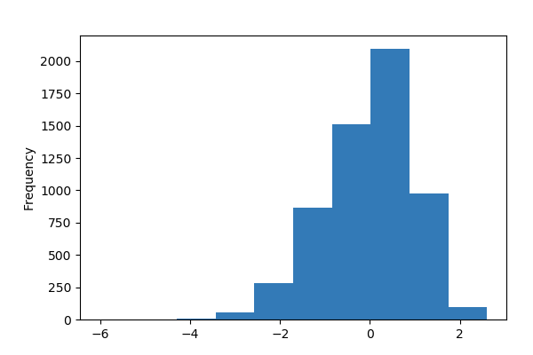

**Common Values**

| Value | Count | Frequency (%) |  |
| --- | --- | --- | --- |
| -0.06909274556255394 | 266 | 4.5% |  |
| 0.7333273402217403 | 191 | 3.2% |  |
| 0.5327223187756667 | 187 | 3.2% |  |
| 0.6664589997397158 | 171 | 2.9% |  |
| 0.39898563781161767 | 169 | 2.9% |  |
| 0.4658539782936422 | 164 | 2.8% |  |
| 0.26524895684756866 | 164 | 2.8% |  |
| 0.9339323616678138 | 164 | 2.8% |  |
| 0.8001956807037648 | 158 | 2.7% |  |
| 0.19838061636554413 | 158 | 2.7% |  |
| Other values (89) | 4100 | 69.6% |  |

**Extreme Values**

Minimum 5 values

| Value | Count | Frequency (%) |  |
| --- | --- | --- | --- |
| -6.020375048462736 | 1 | 0.0% |  |
| -4.616139898340221 | 2 | 0.0% |  |
| -4.014324834002 | 1 | 0.0% |  |
| -3.947456493519976 | 1 | 0.0% |  |
| -3.7468514720739026 | 2 | 0.0% |  |

Maximum 5 values

| Value | Count | Frequency (%) |  |
| --- | --- | --- | --- |
| 2.3381675117903287 | 6 | 0.1% |  |
| 2.4050358522723534 | 5 | 0.1% |  |
| 2.4719041927543777 | 1 | 0.0% |  |
| 2.5387725332364024 | 4 | 0.1% |  |
| 2.6056408737184267 | 1 | 0.0% |  |

DewPointTemp  
Numeric

| Distinct count | 80 |
| --- | --- |
| Unique (%) | 1.4% |
| Missing (%) | 0.0% |
| Missing (n) | 0 |
| Infinite (%) | 0.0% |
| Infinite (n) | 0 |

| Mean | -1.3546e-16 |
| --- | --- |
| Minimum | -3.7488 |
| Maximum | 1.8032 |
| Zeros (%) | 0.0% |

Toggle details

**Statistics**

Quantile statistics

| Minimum | -3.7488 |
| --- | --- |
| 5-th percentile | -1.8618 |
| Q1 | -0.6423 |
| Median | 0.15085 |
| Q3 | 0.81181 |
| 95-th percentile | 1.3406 |
| Maximum | 1.8032 |
| Range | 5.5521 |
| Interquartile range | 1.4541 |

Descriptive statistics

| Standard deviation | 1.0001 |
| --- | --- |
| Coef of variation | -7382800000000000 |
| Kurtosis | -0.26407 |
| Mean | -1.3546e-16 |
| MAD | 0.81864 |
| Skewness | -0.67259 |
| Sum | -5.9686e-13 |
| Variance | 1.0002 |
| Memory size | 46.1 KiB |

**Histogram**

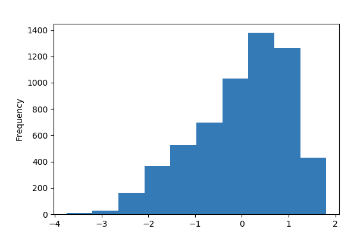

**Common Values**

| Value | Count | Frequency (%) |  |
| --- | --- | --- | --- |
| -0.04744054439313751 | 271 | 4.6% |  |
| 0.7457106144558544 | 189 | 3.2% |  |
| 0.6796146845517718 | 188 | 3.2% |  |
| 0.8118065443599372 | 181 | 3.1% |  |
| 0.8779024742640198 | 179 | 3.0% |  |
| 0.6135187546476891 | 172 | 2.9% |  |
| 0.9439984041681024 | 168 | 2.9% |  |
| 0.5474228247436065 | 161 | 2.7% |  |
| 0.41523096493544115 | 154 | 2.6% |  |
| 0.4813268948395238 | 152 | 2.6% |  |
| Other values (70) | 4077 | 69.2% |  |

**Extreme Values**

Minimum 5 values

| Value | Count | Frequency (%) |  |
| --- | --- | --- | --- |
| -3.7488126190217668 | 1 | 0.0% |  |
| -3.6166207592136015 | 1 | 0.0% |  |
| -3.484428899405436 | 2 | 0.0% |  |
| -3.3522370395972705 | 2 | 0.0% |  |
| -3.220045179789105 | 4 | 0.1% |  |

Maximum 5 values

| Value | Count | Frequency (%) |  |
| --- | --- | --- | --- |
| 1.4727658434007638 | 57 | 1.0% |  |
| 1.5388617733048464 | 36 | 0.6% |  |
| 1.604957703208929 | 21 | 0.4% |  |
| 1.6710536331130117 | 2 | 0.0% |  |
| 1.803245492921177 | 1 | 0.0% |  |

DewPointTemp1  
Numeric

| Distinct count | 81 |
| --- | --- |
| Unique (%) | 1.4% |
| Missing (%) | 0.0% |
| Missing (n) | 0 |
| Infinite (%) | 0.0% |
| Infinite (n) | 0 |

| Mean | 1.522e-16 |
| --- | --- |
| Minimum | -5.3049 |
| Maximum | 1.7392 |
| Zeros (%) | 0.0% |

Toggle details

**Statistics**

Quantile statistics

| Minimum | -5.3049 |
| --- | --- |
| 5-th percentile | -1.9158 |
| Q1 | -0.65316 |
| Median | 0.21074 |
| Q3 | 0.80882 |
| 95-th percentile | 1.274 |
| Maximum | 1.7392 |
| Range | 7.0441 |
| Interquartile range | 1.462 |

Descriptive statistics

| Standard deviation | 1.0001 |
| --- | --- |
| Coef of variation | 6570700000000000 |
| Kurtosis | -0.10776 |
| Mean | 1.522e-16 |
| MAD | 0.81379 |
| Skewness | -0.71666 |
| Sum | 1.1013e-12 |
| Variance | 1.0002 |
| Memory size | 46.1 KiB |

**Histogram**

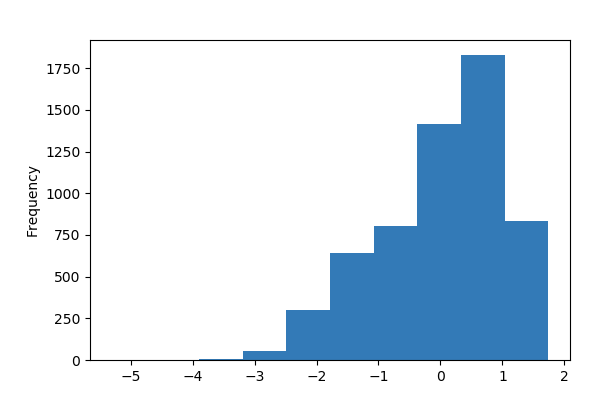

**Common Values**

| Value | Count | Frequency (%) |  |
| --- | --- | --- | --- |
| -0.055073569491420074 | 241 | 4.1% |  |
| 0.6759172529287988 | 197 | 3.3% |  |
| 0.7423709640579096 | 190 | 3.2% |  |
| 0.8752783863161312 | 186 | 3.2% |  |
| 0.609463541799688 | 185 | 3.1% |  |
| 0.4765561195414663 | 173 | 2.9% |  |
| 1.0746395197034635 | 170 | 2.9% |  |
| 0.8088246751870204 | 168 | 2.9% |  |
| 0.21074127502502313 | 166 | 2.8% |  |
| 0.27719498615413396 | 160 | 2.7% |  |
| Other values (71) | 4056 | 68.8% |  |

**Extreme Values**

Minimum 5 values

| Value | Count | Frequency (%) |  |
| --- | --- | --- | --- |
| -5.3049167486911735 | 1 | 0.0% |  |
| -4.108749948367179 | 1 | 0.0% |  |
| -3.710027681592514 | 2 | 0.0% |  |
| -3.5106665482051818 | 1 | 0.0% |  |
| -3.444212837076071 | 2 | 0.0% |  |

Maximum 5 values

| Value | Count | Frequency (%) |  |
| --- | --- | --- | --- |
| 1.4733617864781283 | 49 | 0.8% |  |
| 1.5398154976072391 | 34 | 0.6% |  |
| 1.60626920873635 | 17 | 0.3% |  |
| 1.6727229198654607 | 5 | 0.1% |  |
| 1.7391766309945715 | 3 | 0.1% |  |

Distance  
Numeric

| Distinct count | 933 |
| --- | --- |
| Unique (%) | 15.8% |
| Missing (%) | 0.0% |
| Missing (n) | 0 |
| Infinite (%) | 0.0% |
| Infinite (n) | 0 |

| Mean | -2.8302e-17 |
| --- | --- |
| Minimum | -1.2789 |
| Maximum | 8.0938 |
| Zeros (%) | 0.0% |

Toggle details

**Statistics**

Quantile statistics

| Minimum | -1.2789 |
| --- | --- |
| 5-th percentile | -1.0007 |
| Q1 | -0.72055 |
| Median | -0.28501 |
| Q3 | 0.39227 |
| 95-th percentile | 2.1152 |
| Maximum | 8.0938 |
| Range | 9.3726 |
| Interquartile range | 1.1128 |

Descriptive statistics

| Standard deviation | 1.0001 |
| --- | --- |
| Coef of variation | -3.5336e+16 |
| Kurtosis | 3.9078 |
| Mean | -2.8302e-17 |
| MAD | 0.74619 |
| Skewness | 1.7203 |
| Sum | -2.4336e-13 |
| Variance | 1.0002 |
| Memory size | 46.1 KiB |

**Histogram**

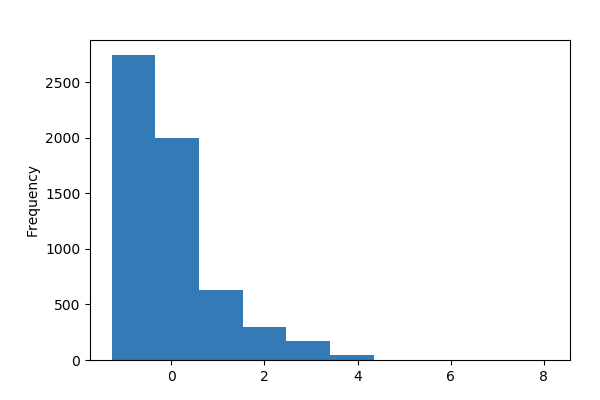

**Common Values**

| Value | Count | Frequency (%) |  |
| --- | --- | --- | --- |
| -0.9527050383399072 | 52 | 0.9% |  |
| -1.0160207847977654 | 36 | 0.6% |  |
| -0.8433414762763338 | 36 | 0.6% |  |
| -0.661068872837045 | 34 | 0.6% |  |
| -0.4922268822827563 | 34 | 0.6% |  |
| -0.7167099833606174 | 32 | 0.5% |  |
| -0.4519350436277556 | 32 | 0.5% |  |
| -0.7800257298184756 | 31 | 0.5% |  |
| -0.9354371074877641 | 31 | 0.5% |  |
| -0.2965236659584672 | 29 | 0.5% |  |
| Other values (923) | 5545 | 94.1% |  |

**Extreme Values**

Minimum 5 values

| Value | Count | Frequency (%) |  |
| --- | --- | --- | --- |
| -1.2788770655470558 | 1 | 0.0% |  |
| -1.27120242961277 | 1 | 0.0% |  |
| -1.2443412038427695 | 1 | 0.0% |  |
| -1.242422544859198 | 1 | 0.0% |  |
| -1.217479978072769 | 1 | 0.0% |  |

Maximum 5 values

| Value | Count | Frequency (%) |  |
| --- | --- | --- | --- |
| 5.833591786552354 | 1 | 0.0% |  |
| 5.914175463862356 | 1 | 0.0% |  |
| 6.601055379980939 | 1 | 0.0% |  |
| 7.211188936756664 | 1 | 0.0% |  |
| 8.093772069199536 | 1 | 0.0% |  |

GroundHeight  
Numeric

| Distinct count | 194 |
| --- | --- |
| Unique (%) | 3.3% |
| Missing (%) | 0.0% |
| Missing (n) | 0 |
| Infinite (%) | 0.0% |
| Infinite (n) | 0 |

| Mean | 1.5621e-17 |
| --- | --- |
| Minimum | -0.67943 |
| Maximum | 4.5039 |
| Zeros (%) | 0.0% |

Toggle details

**Statistics**

Quantile statistics

| Minimum | -0.67943 |
| --- | --- |
| 5-th percentile | -0.66349 |
| Q1 | -0.60646 |
| Median | -0.21058 |
| Q3 | 0.060322 |
| 95-th percentile | 2.8608 |
| Maximum | 4.5039 |
| Range | 5.1833 |
| Interquartile range | 0.66678 |

Descriptive statistics

| Standard deviation | 1.0001 |
| --- | --- |
| Coef of variation | 6.4023e+16 |
| Kurtosis | 7.36 |
| Mean | 1.5621e-17 |
| MAD | 0.58443 |
| Skewness | 2.7793 |
| Sum | -1.1724e-13 |
| Variance | 1.0002 |
| Memory size | 46.1 KiB |

**Histogram**

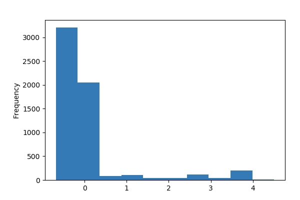

**Common Values**

| Value | Count | Frequency (%) |  |
| --- | --- | --- | --- |
| 0.13496829032410912 | 381 | 6.5% |  |
| -0.21058466024240588 | 321 | 5.4% |  |
| -0.13006746787739268 | 272 | 4.6% |  |
| -0.5804605126691853 | 174 | 3.0% |  |
| 3.8320493730842986 | 164 | 2.8% |  |
| -0.6634938672956051 | 154 | 2.6% |  |
| 0.06032214323571147 | 153 | 2.6% |  |
| -0.40852275813973 | 142 | 2.4% |  |
| -0.6584615427727918 | 141 | 2.4% |  |
| 0.051096214943887046 | 140 | 2.4% |  |
| Other values (184) | 3850 | 65.3% |  |

**Extreme Values**

Minimum 5 values

| Value | Count | Frequency (%) |  |
| --- | --- | --- | --- |
| -0.6794295616178473 | 26 | 0.4% |  |
| -0.6769133993564407 | 1 | 0.0% |  |
| -0.6760746786026385 | 46 | 0.8% |  |
| -0.6735585163412318 | 18 | 0.3% |  |
| -0.6727197955874296 | 72 | 1.2% |  |

Maximum 5 values

| Value | Count | Frequency (%) |  |
| --- | --- | --- | --- |
| 3.80604902971643 | 4 | 0.1% |  |
| 3.8320493730842986 | 164 | 2.8% |  |
| 4.03669723701204 | 1 | 0.0% |  |
| 4.143214772744923 | 1 | 0.0% |  |
| 4.5038646968798774 | 12 | 0.2% |  |

GroundHeight1  
Numeric

| Distinct count | 185 |
| --- | --- |
| Unique (%) | 3.1% |
| Missing (%) | 0.0% |
| Missing (n) | 0 |
| Infinite (%) | 0.0% |
| Infinite (n) | 0 |

| Mean | -1.564e-18 |
| --- | --- |
| Minimum | -0.7039 |
| Maximum | 4.5464 |
| Zeros (%) | 0.0% |

Toggle details

**Statistics**

Quantile statistics

| Minimum | -0.7039 |
| --- | --- |
| 5-th percentile | -0.68776 |
| Q1 | -0.62319 |
| Median | -0.21879 |
| Q3 | 0.061563 |
| 95-th percentile | 2.8821 |
| Maximum | 4.5464 |
| Range | 5.2503 |
| Interquartile range | 0.68475 |

Descriptive statistics

| Standard deviation | 1.0001 |
| --- | --- |
| Coef of variation | -6.3946e+17 |
| Kurtosis | 7.186 |
| Mean | -1.564e-18 |
| MAD | 0.58809 |
| Skewness | 2.732 |
| Sum | -2.629e-13 |
| Variance | 1.0002 |
| Memory size | 46.1 KiB |

**Histogram**

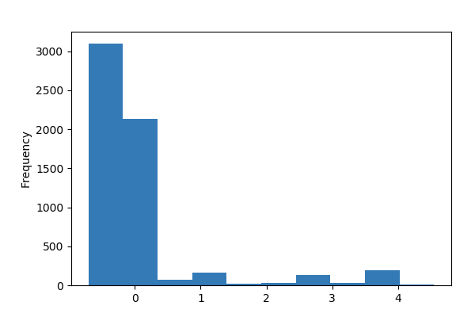

**Common Values**

| Value | Count | Frequency (%) |  |
| --- | --- | --- | --- |
| 0.12103259879045218 | 459 | 7.8% |  |
| -0.22898946194633704 | 332 | 5.6% |  |
| 0.045421037126437025 | 259 | 4.4% |  |
| -0.1474309235222308 | 252 | 4.3% |  |
| -0.603648997832075 | 183 | 3.1% |  |
| -0.682658831930428 | 167 | 2.8% |  |
| -0.4294875355722649 | 164 | 2.8% |  |
| 3.865928821430663 | 154 | 2.6% |  |
| 0.23317558912359823 | 152 | 2.6% |  |
| 1.1031333323140646 | 150 | 2.5% |  |
| Other values (175) | 3620 | 61.4% |  |

**Extreme Values**

Minimum 5 values

| Value | Count | Frequency (%) |  |
| --- | --- | --- | --- |
| -0.703898034645039 | 11 | 0.2% |  |
| -0.7013493303192856 | 1 | 0.0% |  |
| -0.7004997622107012 | 45 | 0.8% |  |
| -0.6979510578849478 | 22 | 0.4% |  |
| -0.6971014897763634 | 54 | 0.9% |  |

Maximum 5 values

| Value | Count | Frequency (%) |  |
| --- | --- | --- | --- |
| 3.8030607813954145 | 32 | 0.5% |  |
| 3.8395922100645454 | 6 | 0.1% |  |
| 3.865928821430663 | 154 | 2.6% |  |
| 4.18111858971549 | 6 | 0.1% |  |
| 4.546432876406799 | 5 | 0.1% |  |

HourlyPrecip  
Numeric

| Distinct count | 59 |
| --- | --- |
| Unique (%) | 1.0% |
| Missing (%) | 0.0% |
| Missing (n) | 0 |
| Infinite (%) | 0.0% |
| Infinite (n) | 0 |

| Mean | 1.7335e-17 |
| --- | --- |
| Minimum | -0.14871 |
| Maximum | 25.347 |
| Zeros (%) | 0.0% |

Toggle details

**Statistics**

Quantile statistics

| Minimum | -0.14871 |
| --- | --- |
| 5-th percentile | -0.14871 |
| Q1 | -0.14871 |
| Median | -0.14871 |
| Q3 | -0.14871 |
| 95-th percentile | 0.281 |
| Maximum | 25.347 |
| Range | 25.496 |
| Interquartile range | 0 |

Descriptive statistics

| Standard deviation | 1.0001 |
| --- | --- |
| Coef of variation | 5.769e+16 |
| Kurtosis | 232.79 |
| Mean | 1.7335e-17 |
| MAD | 0.27162 |
| Skewness | 13.127 |
| Sum | -1.4211e-14 |
| Variance | 1.0002 |
| Memory size | 46.1 KiB |

**Histogram**

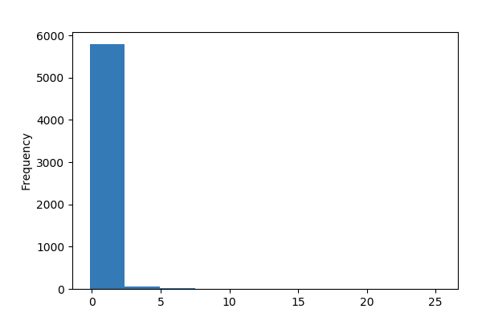

**Common Values**

| Value | Count | Frequency (%) |  |
| --- | --- | --- | --- |
| -0.14870641624072367 | 5376 | 91.2% |  |
| -0.005469828944607308 | 138 | 2.3% |  |
| 0.13776675835150906 | 63 | 1.1% |  |
| 0.2810033456476254 | 44 | 0.7% |  |
| 0.4242399329437418 | 27 | 0.5% |  |
| 0.7107131075359745 | 24 | 0.4% |  |
| 0.5674765202398582 | 19 | 0.3% |  |
| 0.853949694832091 | 16 | 0.3% |  |
| 1.4268960440165563 | 16 | 0.3% |  |
| 0.9971862821282071 | 12 | 0.2% |  |
| Other values (49) | 157 | 2.7% |  |

**Extreme Values**

Minimum 5 values

| Value | Count | Frequency (%) |  |
| --- | --- | --- | --- |
| -0.14870641624072367 | 5376 | 91.2% |  |
| -0.005469828944607308 | 138 | 2.3% |  |
| 0.13776675835150906 | 63 | 1.1% |  |
| 0.2810033456476254 | 44 | 0.7% |  |
| 0.4242399329437418 | 27 | 0.5% |  |

Maximum 5 values

| Value | Count | Frequency (%) |  |
| --- | --- | --- | --- |
| 14.891135249851496 | 1 | 0.0% |  |
| 15.034371837147612 | 1 | 0.0% |  |
| 15.464081599035962 | 1 | 0.0% |  |
| 23.05562072573013 | 2 | 0.0% |  |
| 25.34740612246799 | 1 | 0.0% |  |

HourlyPrecip1  
Numeric

| Distinct count | 54 |
| --- | --- |
| Unique (%) | 0.9% |
| Missing (%) | 0.0% |
| Missing (n) | 0 |
| Infinite (%) | 0.0% |
| Infinite (n) | 0 |

| Mean | 4.4334e-16 |
| --- | --- |
| Minimum | -0.12627 |
| Maximum | 32.461 |
| Zeros (%) | 0.0% |

Toggle details

**Statistics**

Quantile statistics

| Minimum | -0.12627 |
| --- | --- |
| 5-th percentile | -0.12627 |
| Q1 | -0.12627 |
| Median | -0.12627 |
| Q3 | -0.12627 |
| 95-th percentile | 0.056799 |
| Maximum | 32.461 |
| Range | 32.587 |
| Interquartile range | 0 |

Descriptive statistics

| Standard deviation | 1.0001 |
| --- | --- |
| Coef of variation | 2255800000000000 |
| Kurtosis | 340.28 |
| Mean | 4.4334e-16 |
| MAD | 0.23583 |
| Skewness | 15.738 |
| Sum | -7.816e-14 |
| Variance | 1.0002 |
| Memory size | 46.1 KiB |

**Histogram**

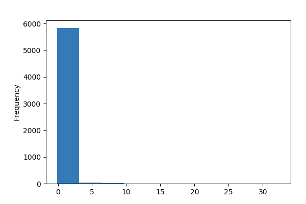

**Common Values**

| Value | Count | Frequency (%) |  |
| --- | --- | --- | --- |
| -0.12627482413762545 | 5502 | 93.4% |  |
| 0.05679881361308546 | 123 | 2.1% |  |
| 0.23987245136379637 | 45 | 0.8% |  |
| 0.4229460891145072 | 24 | 0.4% |  |
| 0.6060197268652181 | 22 | 0.4% |  |
| 1.5213879156187726 | 20 | 0.3% |  |
| 0.789093364615929 | 19 | 0.3% |  |
| 0.9721670023666399 | 14 | 0.2% |  |
| 1.8875351911201945 | 10 | 0.2% |  |
| 1.7044615533694838 | 9 | 0.2% |  |
| Other values (44) | 104 | 1.8% |  |

**Extreme Values**

Minimum 5 values

| Value | Count | Frequency (%) |  |
| --- | --- | --- | --- |
| -0.12627482413762545 | 5502 | 93.4% |  |
| 0.05679881361308546 | 123 | 2.1% |  |
| 0.23987245136379637 | 45 | 0.8% |  |
| 0.4229460891145072 | 24 | 0.4% |  |
| 0.6060197268652181 | 22 | 0.4% |  |

Maximum 5 values

| Value | Count | Frequency (%) |  |
| --- | --- | --- | --- |
| 16.899573486678488 | 1 | 0.0% |  |
| 19.27953077743773 | 1 | 0.0% |  |
| 20.011825328440572 | 1 | 0.0% |  |
| 21.47641443044626 | 1 | 0.0% |  |
| 32.46083269548891 | 1 | 0.0% |  |

New_SkyConditions  
Numeric

| Distinct count | 2781 |
| --- | --- |
| Unique (%) | 47.2% |
| Missing (%) | 0.0% |
| Missing (n) | 0 |
| Infinite (%) | 0.0% |
| Infinite (n) | 0 |

| Mean | 6.937e-17 |
| --- | --- |
| Minimum | -1.7684 |
| Maximum | 1.789 |
| Zeros (%) | 0.0% |

Toggle details

**Statistics**

Quantile statistics

| Minimum | -1.7684 |
| --- | --- |
| 5-th percentile | -1.4963 |
| Q1 | -1.0252 |
| Median | 0.10875 |
| Q3 | 0.66226 |
| 95-th percentile | 1.6682 |
| Maximum | 1.789 |
| Range | 3.5574 |
| Interquartile range | 1.6875 |

Descriptive statistics

| Standard deviation | 1.0001 |
| --- | --- |
| Coef of variation | 1.4417e+16 |
| Kurtosis | -1.1914 |
| Mean | 6.937e-17 |
| MAD | 0.87983 |
| Skewness | 0.078673 |
| Sum | -2.1316e-14 |
| Variance | 1.0002 |
| Memory size | 46.1 KiB |

**Histogram**

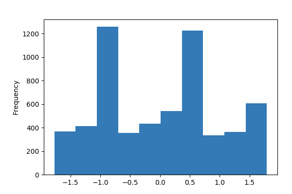

**Common Values**

| Value | Count | Frequency (%) |  |
| --- | --- | --- | --- |
| -1.0252213542950734 | 827 | 14.0% |  |
| 0.6332328188825453 | 141 | 2.4% |  |
| 1.7817123338080463 | 81 | 1.4% |  |
| -1.0272944220115454 | 73 | 1.2% |  |
| 0.6197578787254772 | 67 | 1.1% |  |
| 0.23520381731991685 | 34 | 0.6% |  |
| 0.11807549133924751 | 31 | 0.5% |  |
| 1.7765296645168662 | 29 | 0.5% |  |
| 0.5389082377830683 | 29 | 0.5% |  |
| 0.6404885558901975 | 25 | 0.4% |  |
| Other values (2771) | 4555 | 77.3% |  |

**Extreme Values**

Minimum 5 values

| Value | Count | Frequency (%) |  |
| --- | --- | --- | --- |
| -1.768416130650294 | 1 | 0.0% |  |
| -1.7673795967920578 | 1 | 0.0% |  |
| -1.766343062933822 | 1 | 0.0% |  |
| -1.7642699952173497 | 1 | 0.0% |  |
| -1.7632334613591139 | 2 | 0.0% |  |

Maximum 5 values

| Value | Count | Frequency (%) |  |
| --- | --- | --- | --- |
| 1.7848219353827544 | 10 | 0.2% |  |
| 1.7858584692409905 | 5 | 0.1% |  |
| 1.7868950030992263 | 2 | 0.0% |  |
| 1.7879315369574624 | 1 | 0.0% |  |
| 1.7889680708156985 | 1 | 0.0% |  |

New_SkyConditions1  
Numeric

| Distinct count | 2753 |
| --- | --- |
| Unique (%) | 46.7% |
| Missing (%) | 0.0% |
| Missing (n) | 0 |
| Infinite (%) | 0.0% |
| Infinite (n) | 0 |

| Mean | -2.3817e-17 |
| --- | --- |
| Minimum | -1.7656 |
| Maximum | 1.7678 |
| Zeros (%) | 0.0% |

Toggle details

**Statistics**

Quantile statistics

| Minimum | -1.7656 |
| --- | --- |
| 5-th percentile | -1.4486 |
| Q1 | -1.0873 |
| Median | 0.11894 |
| Q3 | 0.65439 |
| 95-th percentile | 1.6725 |
| Maximum | 1.7678 |
| Range | 3.5333 |
| Interquartile range | 1.7417 |

Descriptive statistics

| Standard deviation | 1.0001 |
| --- | --- |
| Coef of variation | -4.199e+16 |
| Kurtosis | -1.2108 |
| Mean | -2.3817e-17 |
| MAD | 0.87842 |
| Skewness | 0.065124 |
| Sum | 1.4211e-14 |
| Variance | 1.0002 |
| Memory size | 46.1 KiB |

**Histogram**

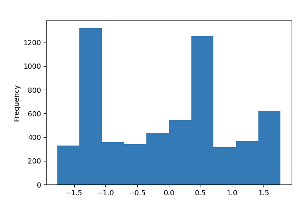

**Common Values**

| Value | Count | Frequency (%) |  |
| --- | --- | --- | --- |
| -1.0873123243485336 | 791 | 13.4% |  |
| 0.6263476474754477 | 191 | 3.2% |  |
| 1.762612277441619 | 104 | 1.8% |  |
| -1.0903999999734417 | 89 | 1.5% |  |
| 0.6129677197675126 | 64 | 1.1% |  |
| 0.17760545665547414 | 35 | 0.6% |  |
| 0.035572377909702704 | 33 | 0.6% |  |
| 0.5316589283116 | 32 | 0.5% |  |
| 0.6386983499750799 | 27 | 0.5% |  |
| -0.19085716791688942 | 27 | 0.5% |  |
| Other values (2743) | 4499 | 76.4% |  |

**Extreme Values**

Minimum 5 values

| Value | Count | Frequency (%) |  |
| --- | --- | --- | --- |
| -1.7655717366200074 | 1 | 0.0% |  |
| -1.7645425114117048 | 1 | 0.0% |  |
| -1.763513286203402 | 1 | 0.0% |  |
| -1.7614548357867967 | 1 | 0.0% |  |
| -1.760425610578494 | 1 | 0.0% |  |

Maximum 5 values

| Value | Count | Frequency (%) |  |
| --- | --- | --- | --- |
| 1.7636415026499217 | 1 | 0.0% |  |
| 1.7646707278582245 | 8 | 0.1% |  |
| 1.7656999530665272 | 11 | 0.2% |  |
| 1.7667291782748298 | 2 | 0.0% |  |
| 1.7677584034831326 | 1 | 0.0% |  |

RelativeHumidityPercent  
Numeric

| Distinct count | 93 |
| --- | --- |
| Unique (%) | 1.6% |
| Missing (%) | 0.0% |
| Missing (n) | 0 |
| Infinite (%) | 0.0% |
| Infinite (n) | 0 |

| Mean | -8.109e-17 |
| --- | --- |
| Minimum | -2.8025 |
| Maximum | 1.734 |
| Zeros (%) | 0.0% |

Toggle details

**Statistics**

Quantile statistics

| Minimum | -2.8025 |
| --- | --- |
| 5-th percentile | -1.8574 |
| Q1 | -0.676 |
| Median | -0.014436 |
| Q3 | 0.78889 |
| 95-th percentile | 1.4505 |
| Maximum | 1.734 |
| Range | 4.5364 |
| Interquartile range | 1.4649 |

Descriptive statistics

| Standard deviation | 1.0001 |
| --- | --- |
| Coef of variation | -1.2333e+16 |
| Kurtosis | -0.48259 |
| Mean | -8.109e-17 |
| MAD | 0.81119 |
| Skewness | -0.35443 |
| Sum | -3.8369e-13 |
| Variance | 1.0002 |
| Memory size | 46.1 KiB |

**Histogram**

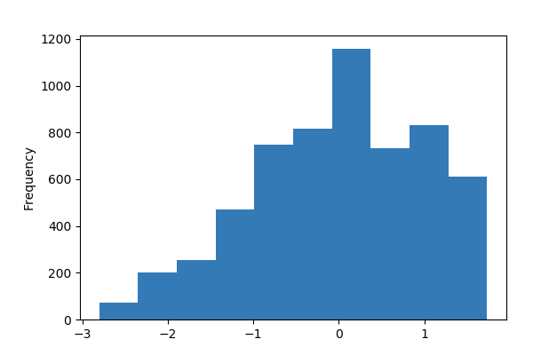

**Common Values**

| Value | Count | Frequency (%) |  |
| --- | --- | --- | --- |
| -0.014436237536298227 | 273 | 4.6% |  |
| 1.4032022885281807 | 192 | 3.3% |  |
| 1.2614384359217328 | 149 | 2.5% |  |
| 0.26909146767659753 | 130 | 2.2% |  |
| 0.7416376430314239 | 125 | 2.1% |  |
| 0.5998737904249759 | 122 | 2.1% |  |
| -0.10894547260726349 | 115 | 2.0% |  |
| -0.4397277953556419 | 114 | 1.9% |  |
| 0.1745822326056323 | 113 | 1.9% |  |
| -0.061690855071780855 | 112 | 1.9% |  |
| Other values (83) | 4447 | 75.5% |  |

**Extreme Values**

Minimum 5 values

| Value | Count | Frequency (%) |  |
| --- | --- | --- | --- |
| -2.8024586721297733 | 2 | 0.0% |  |
| -2.707949437058808 | 2 | 0.0% |  |
| -2.6606948195233255 | 5 | 0.1% |  |
| -2.6134402019878427 | 9 | 0.2% |  |
| -2.5661855844523602 | 8 | 0.1% |  |

Maximum 5 values

| Value | Count | Frequency (%) |  |
| --- | --- | --- | --- |
| 1.4032022885281807 | 192 | 3.3% |  |
| 1.4504569060636632 | 69 | 1.2% |  |
| 1.5449661411346285 | 105 | 1.8% |  |
| 1.5922207586701111 | 81 | 1.4% |  |
| 1.7339846112765591 | 99 | 1.7% |  |

RelativeHumidityPercent1  
Numeric

| Distinct count | 94 |
| --- | --- |
| Unique (%) | 1.6% |
| Missing (%) | 0.0% |
| Missing (n) | 0 |
| Infinite (%) | 0.0% |
| Infinite (n) | 0 |

| Mean | 9.1463e-17 |
| --- | --- |
| Minimum | -2.7156 |
| Maximum | 1.8442 |
| Zeros (%) | 0.0% |

Toggle details

**Statistics**

Quantile statistics

| Minimum | -2.7156 |
| --- | --- |
| 5-th percentile | -1.8606 |
| Q1 | -0.67321 |
| Median | -0.0082468 |
| Q3 | 0.75171 |
| 95-th percentile | 1.5117 |
| Maximum | 1.8442 |
| Range | 4.5598 |
| Interquartile range | 1.4249 |

Descriptive statistics

| Standard deviation | 1.0001 |
| --- | --- |
| Coef of variation | 1.0934e+16 |
| Kurtosis | -0.43416 |
| Mean | 9.1463e-17 |
| MAD | 0.80761 |
| Skewness | -0.32255 |
| Sum | 6.3238e-13 |
| Variance | 1.0002 |
| Memory size | 46.1 KiB |

**Histogram**

[15 more figures not shown]

Sample

|  | Distance | GroundHeight | StationHeight | BarometerHeight | Visibility | DBT | DewPointTemp | RelativeHumidityPercent | WindSpeed | WindDirection | WindGustValue | StationPressure | HourlyPrecip | GroundHeight1 | StationHeight1 | BarometerHeight1 | Visibility1 | DBT1 | DewPointTemp1 | RelativeHumidityPercent1 | WindSpeed1 | WindDirection1 | WindGustValue1 | StationPressure1 | HourlyPrecip1 | New_SkyConditions | New_SkyConditions1 | Speed |
| --- | --- | --- | --- | --- | --- | --- | --- | --- | --- | --- | --- | --- | --- | --- | --- | --- | --- | --- | --- | --- | --- | --- | --- | --- | --- | --- | --- | --- |
| 3892 | -0.639964 | 4.503865 | 4.459093 | 4.511523 | 0.494520 | 0.808571 | -1.699839 | -2.329912 | -0.063387 | 0.168154 | -0.381713 | -4.297434 | -0.148706 | 2.882129 | 2.852788 | 2.887608 | 0.439136 | 0.867064 | -1.450602 | -2.145634 | 2.774769 | -0.018021 | 3.304050 | -3.058051 | -0.126275 | 0.538908 | 0.418444 | -0.781435 |
| 6722 | 0.461347 | -0.210585 | -0.183428 | -0.213534 | 0.494520 | 0.345594 | 0.679615 | 0.363601 | 2.074441 | 0.079016 | -0.381713 | 0.105889 | -0.148706 | -0.623189 | -0.616028 | -0.626540 | 0.439136 | 0.398986 | 0.343649 | -0.293232 | 0.154362 | -0.472167 | -0.374439 | 0.827413 | -0.126275 | -0.400191 | -1.196410 | 1.261334 |
| 6729 | -0.634208 | 0.000228 | 0.000778 | 0.000223 | 0.494520 | -0.051244 | -0.047441 | -0.014436 | -0.063387 | -1.436320 | 0.018308 | -0.149257 | -0.148706 | 0.008040 | 0.007703 | 0.007983 | 0.439136 | -0.069093 | -0.055074 | -0.008247 | -0.064005 | -1.471288 | -0.006590 | -0.129393 | -0.126275 | -1.025221 | -1.087312 | -0.600756 |
| 2453 | -0.751246 | -0.639171 | -0.656508 | -0.643085 | -3.254227 | -0.051244 | -0.047441 | -0.014436 | 0.150395 | 1.505216 | 2.018414 | -0.149257 | -0.148706 | 0.121033 | 0.158374 | 0.119556 | 0.439136 | 0.265249 | 0.609464 | 0.371733 | 0.809464 | 0.526954 | 1.941647 | -0.304114 | -0.126275 | 0.792859 | -1.105838 | -0.757182 |
| 7435 | 1.570332 | -0.663494 | -0.654843 | -0.534646 | 0.494520 | 0.345594 | 0.481327 | 0.032818 | 0.150395 | 0.435566 | -0.381713 | 0.377496 | -0.148706 | -0.228989 | -0.203575 | -0.231347 | 0.439136 | 1.602616 | 0.941732 | -0.910699 | 0.372729 | 0.345296 | -0.374439 | 0.153489 | -0.126275 | 0.618721 | -1.088342 | 1.179726 |

```python
# overview of X_train

import pandas_profiling as pp
pp.ProfileReport(X_train)
```

```python
#remove highly correlated features

X_train=X_train.drop('StationHeight',axis=1)
X_test=X_test.drop('StationHeight',axis=1)

X_train=X_train.drop('StationHeight1',axis=1)
X_test=X_test.drop('StationHeight1',axis=1)

final_testA=final_testA.drop('StationHeight',axis=1)
final_testA=final_testA.drop('StationHeight1',axis=1)
```

```python
#check vif
from statsmodels.stats.outliers_influence import variance_inflation_factor
Xdata=X_train
Xdata['intercept']=1
Xdata=Xdata
vif=pd.DataFrame()
vif['Vif']=[variance_inflation_factor(Xdata.values,i) for i in range(Xdata.shape[1])]
vif['Variables']=Xdata.columns.values
```

```python
vif
```

|  | Vif | Variables |
| --- | --- | --- |
| 0 | 3.458288 | Distance |
| 1 | 2940.908482 | GroundHeight |
| 2 | 2859.936484 | BarometerHeight |
| 3 | 1.637534 | Visibility |
| 4 | 22.562064 | DBT |
| 5 | 24.408762 | DewPointTemp |
| 6 | 16.037561 | RelativeHumidityPercent |
| 7 | 1.789086 | WindSpeed |
| 8 | 1.160906 | WindDirection |
| 9 | 1.601727 | WindGustValue |
| 10 | 45.373862 | StationPressure |
| 11 | 1.134664 | HourlyPrecip |
| 12 | 3063.493158 | GroundHeight1 |
| 13 | 2967.718593 | BarometerHeight1 |
| 14 | 1.484871 | Visibility1 |
| 15 | 18.769301 | DBT1 |
| 16 | 20.321773 | DewPointTemp1 |
| 17 | 14.469768 | RelativeHumidityPercent1 |
| 18 | 1.739893 | WindSpeed1 |
| 19 | 1.161697 | WindDirection1 |
| 20 | 1.555593 | WindGustValue1 |
| 21 | 55.087497 | StationPressure1 |
| 22 | 1.099653 | HourlyPrecip1 |
| 23 | 1.024188 | New_SkyConditions |
| 24 | 1.030756 | New_SkyConditions1 |
| 25 | 3.460686 | Speed |
| 26 | 1.000000 | intercept |

```python
#remove high vif features
X_train=X_train.drop('GroundHeight',axis=1)
X_train=X_train.drop('GroundHeight1',axis=1)

X_test=X_test.drop('BarometerHeight1',axis=1)
X_test=X_test.drop('BarometerHeight',axis=1)
```

```python
#remove high vif features
X_train=X_train.drop('BarometerHeight1',axis=1)
X_train=X_train.drop('BarometerHeight',axis=1)

X_test=X_test.drop('GroundHeight',axis=1)
X_test=X_test.drop('GroundHeight1',axis=1)
```

```python
final_testA=final_testA.drop('BarometerHeight',axis=1)
final_testA=final_testA.drop('GroundHeight',axis=1)

final_testA=final_testA.drop('BarometerHeight1',axis=1)
final_testA=final_testA.drop('GroundHeight1',axis=1)
```

```python
X_train=X_train.drop('intercept',axis=1)
```

```python
#using smote to overcome class imbalance

from imblearn.over_sampling import SMOTE
sm=SMOTE(random_state=42)
```

```python
X_train_sm, y_train_sm =sm.fit_sample(X_train,y_train)
```

Building Model

# Random Forest Model

```python
from sklearn.ensemble import RandomForestClassifier
model = RandomForestClassifier(n_estimators=100,max_depth=8,n_jobs=1)
model.fit(X_train_sm, y_train_sm)
```

```
RandomForestClassifier(bootstrap=True, class_weight=None, criterion='gini',
            max_depth=8, max_features='auto', max_leaf_nodes=None,
            min_impurity_decrease=0.0, min_impurity_split=None,
            min_samples_leaf=1, min_samples_split=2,
            min_weight_fraction_leaf=0.0, n_estimators=100, n_jobs=1,
            oob_score=False, random_state=None, verbose=0,
            warm_start=False)
```

```python
#predicting on train and test data
pred_test = model.predict(X_test)
pred_train = model.predict(X_train_sm)
from sklearn.metrics import classification_report,accuracy_score
from sklearn.metrics import confusion_matrix
print(classification_report(y_train_sm, pred_train))
print(classification_report(y_test, pred_test))
print(accuracy_score(y_test, pred_test))
```

```
              precision    recall  f1-score   support

           1       0.85      0.89      0.87      4738
           2       0.89      0.84      0.86      4738

   micro avg       0.87      0.87      0.87      9476
   macro avg       0.87      0.87      0.87      9476
weighted avg       0.87      0.87      0.87      9476

              precision    recall  f1-score   support

           1       0.42      0.66      0.51       360
           2       0.91      0.79      0.85      1604

   micro avg       0.77      0.77      0.77      1964
   macro avg       0.67      0.73      0.68      1964
weighted avg       0.82      0.77      0.79      1964

0.7693482688391039
```

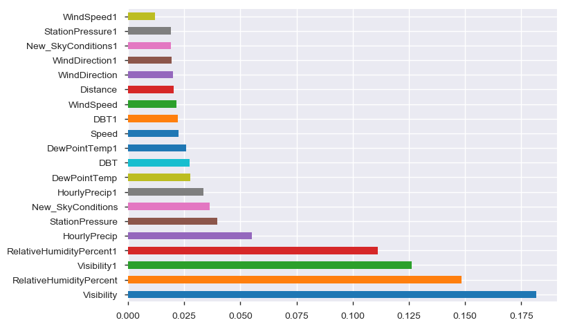

```python
# Features importance plot

feat_importances = pd.Series(model.feature_importances_, index=X_train.columns)
feat_importances = feat_importances.sort_values(ascending=False)
feat_importances.nlargest(20).plot(kind='barh')
```

```python
#saving predictions done on test data to csv

test_pred2= model.predict(final_testA)
sample = pd.read_csv('flightdelay_samplesubmission-1550836789630.csv')
sub = pd.DataFrame()
sub['FlightNumber'] = sample.FlightNumber
sub['FlightDelayStatus'] = test_pred2
sub.to_csv('ssk.csv')
```

Building another model

# XG Boost

```python
import xgboost as xgb
from xgboost import XGBClassifier
model_xgb=XGBClassifier(n_estimators=100,max_depth=2)
model_xgb.fit(X_train_sm,y_train_sm)
```

```
XGBClassifier(base_score=0.5, booster='gbtree', colsample_bylevel=1,
       colsample_bytree=1, gamma=0, learning_rate=0.1, max_delta_step=0,
       max_depth=2, min_child_weight=1, missing=None, n_estimators=100,
       n_jobs=1, nthread=None, objective='binary:logistic', random_state=0,
       reg_alpha=0, reg_lambda=1, scale_pos_weight=1, seed=None,
       silent=True, subsample=1)
```

```python
print("Train accuracy is ",accuracy_score(y_train_sm,model_xgb.predict(X_train_sm)))
print("Test accuracy is",accuracy_score(y_test,model_xgb.predict(X_test.as_matrix())))
```

```
Train accuracy is  0.8163782186576615
Test accuracy is 0.7678207739307535
```

```python
print("Train accuracy is ",classification_report(y_train_sm,model_xgb.predict(X_train_sm)))
print("Test accuracy is",classification_report(y_test,model_xgb.predict(X_test.as_matrix())))
```

```
Train accuracy is                precision    recall  f1-score   support

           1       0.81      0.82      0.82      4738
           2       0.82      0.81      0.82      4738

   micro avg       0.82      0.82      0.82      9476
   macro avg       0.82      0.82      0.82      9476
weighted avg       0.82      0.82      0.82      9476

Test accuracy is               precision    recall  f1-score   support

           1       0.41      0.63      0.50       360
           2       0.91      0.80      0.85      1604

   micro avg       0.77      0.77      0.77      1964
   macro avg       0.66      0.72      0.67      1964
weighted avg       0.82      0.77      0.78      1964
```

```python
Saving predictions

test_pred2= model_xgb.predict(final_testA.as_matrix())
sample = pd.read_csv('flightdelay_samplesubmission-1550836789630.csv')
sub = pd.DataFrame()
sub['FlightNumber'] = sample.FlightNumber
sub['FlightDelayStatus'] = test_pred2
sub.to_csv('trail3.csv')
```

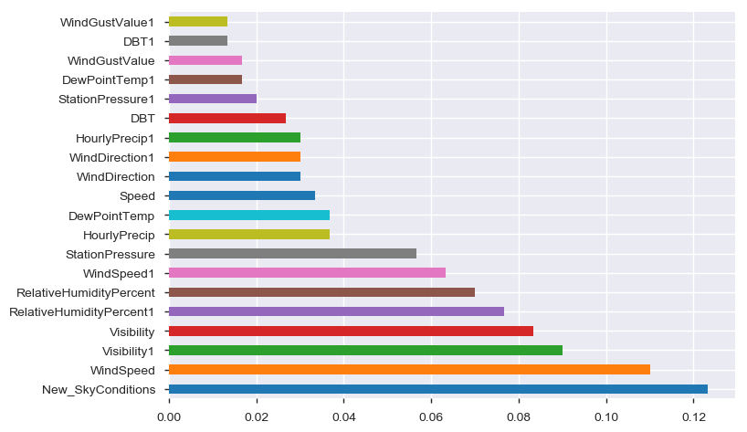

```python
feat_importances = pd.Series(model_xgb.feature_importances_, index=X_train.columns)
feat_importances = feat_importances.sort_values(ascending=False)
feat_importances.nlargest(20).plot(kind='barh')
```

# Summary :

In this project I have used Machine Learning Algorithms to predict Flight Status: Delay or Not Delay. I have used a Ensemble Techniques and I found that this technique works the best.

Model Performance:

Random forest model and Xg Boost Both gave almost same performance, Accuracy turn out to be 76% on validation(x_test) With F1 Score as 0.51.

Conclusion : Most Important Features found: Visibility,Sky Conditons, Wind Speed, Relative Humidity,Hourly Precip.

Best F1 Scores got on Test Data as per the prediction by models:

1. Random Forest = 0.46
2. Xg Boost = 0.45